# LaTeX 과 PDF

LaTeX 판형과 판면 레이아웃

이광춘

[Tidyverse Korea](https://www.facebook.com/groups/tidyverse/)

2021-03-05

# 1 종이 크기[^1]

종이 크기(Standard Paper Size)는 수많은 표준이 있으며 나라와 시기에 따라 다르다. 오늘날 쓰이는 크기에는 대한민국에서 활용하는 국제 표준인 **ISO A형(A4 등 A 계열)**과 북아메리카(North American) 미국 종이 크기가 있다. 국제 종이 크기 표준은 ISO 216이며 이를 따라 제작한 종이를 흔히 ISO A형이라고도 한다. A형 전지는 A0로 표기하며 이를 접어서 절단할 때마다 숫자를 늘린다. A1은 한번 접어서 자른 크기이며, 흔히 사용하는 A4는 A0를 네 번 접어서 자른 종이 크기이다. 가장 많이 사용되고 있는 A4는 가로 x 세로 $210 mm \times 297 mm$ 크기를 갖는다.

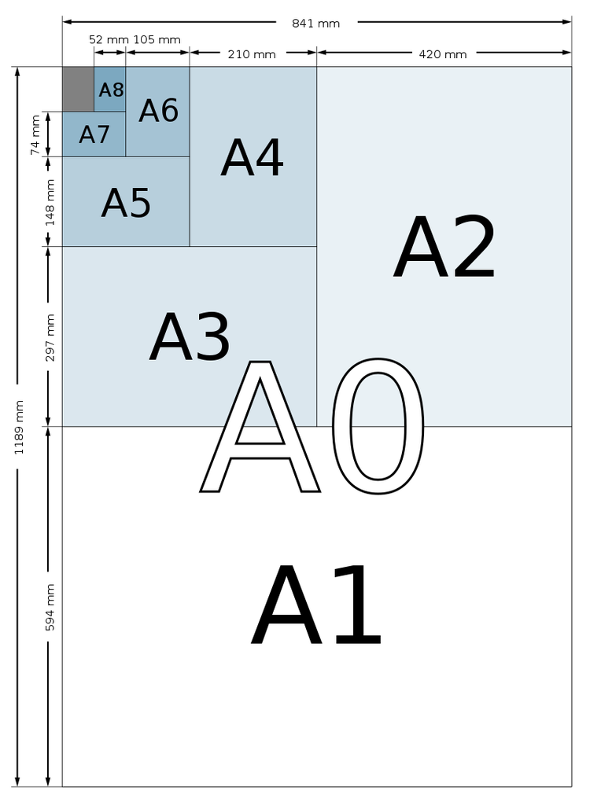

# 2 레이아웃 팩키지[^2]

`geometry`가 문서 레이아웃을 자유로이 지정하는 대표적인 팩키지다. 이외에도 국내에서 많이 사용되는 `memoir`, `oblivoir` 팩키지를 사용할 수 있다.

- `geometry` 팩키지: 판형과 판면을 설정하는 대표적인 팩키지. `showcrop`과 `showframe` 옵션을 주어 재단선을 그려준다.
- `memoir`, `oblivoir` 클래스: 클래스 옵션으로 `showtrmis`를 주고 `\trimLmarks`, `\trimXmarks`, `\trimFrame` 명령을 줄 수 있고 `QuarkXpress`에서 작업한 것과 비슷한 모양으로 그려주는 `\quarkmarks` 명령도 제공.
- `crop` 팩키지: `\crop` 명령과 cam, cross, frame, axes, noaxes 옵션 설정 가능.

`documentclass` 선택사양을 지정하면 문서를 원하는 방향으로 작성할 수 있다. `class_name`에 지정할 수 있는 것은 `book`, `article`, `report`, `letter` 등이 대표적이다.

- `\documentclass[option1, option2, etc.]{class_name}`
  - Font size (10pt, 11pt, 12pt)
  - Paper size and format (a4paper, letterpaper, etc.)
  - Draft mode (draft)
  - Multiple columns (onecolumn, twocolumn)
  - Formula-specific options (fleqn and leqno)
  - Landscape print mode (landscape)
  - Single- and double-sided documents (oneside, twoside)
  - Titlepage behavior (notitlepage, titlepage)
  - Chapter opening page (openright, openany)

**`article`, `report`, `book`**

10 ~ 12pt 만 가능.

**`extrarticle`, `extreport`, `extbook`**

글꼴 크기를 8 ~ 12pt, 14pt, 17pt, 20pt 범위에서 나름 자유롭게 선택가능.

```latex
\documentclass[a4paper]{article}
\usepackage{kotex}
\usepackage{jiwonlipsum}
\usepackage{layout}

\usepackage[showframe]{geometry}
\geometry{
    a4paper,
    landscape,
    left=50mm,
    top=30mm,
    showcrop}

\begin{document}
    \layout
    \tiny
    \jiwon[1-2]
\end{document}
```

```r
knitr::include_graphics("lipsum/layout/layout-geometry.pdf")
```

[figure not shown]

[^1]: [위키백과, “종이 크기”](https://ko.wikipedia.org/wiki/종이_크기)
[^2]: [tom (2013-02-13), “LaTeX documentclass options illustrated”, texblog because LaTeX matters](https://texblog.org/2013/02/13/latex-documentclass-options-illustrated/)

데이터 과학자 [이광춘](https://github.com/statkclee/) 저작

*kwangchun.lee.7@gmail.com*